# IODS course project

## The hypotheses

I will study the relationship between high/low alcohol consumption and four other variables: Pstatus, Medu, Fedu and famrel

My personal hypothesis about these four variables and alcohol consumption are as follows:  
Pstatus = parents´ cohabitation status (living together or apart): My hypothesis is that students whose parents are living together could have lower risk of high alcohol consumption. Medu and Fedu = mother’s education and father´s education: My hypothesis is that parents´lower education (and therefore possibly lower socio economical status) could increase the risk of high alcohol consumption.  
famrel = quality of family relationships: My hypothesis here is that students whose family relationships are graded 4 or 5 could have lower risk of high alcohol consumption.

## Exploring the distributions

### Parents´cohabilitation status

```r
alc %>% group_by(Pstatus, high_use) %>% summarise(count = n())
```

```
## Source: local data frame [4 x 3]
## Groups: Pstatus [?]
##
##   Pstatus high_use count
##    <fctr>    <lgl> <int>
## 1       A    FALSE    26
## 2       A     TRUE    12
## 3       T    FALSE   242
## 4       T     TRUE   102
```

Within students whose parents´cohabilitation status is A = “apart” 26 (68%) students´ alcohol usage is low and 12 (32%) it is high. Within students whose parents live together (status = T) 242 (70%) students´ alcohol usage is low and 102 (30%) it is high.

### Mother´s education level

```r
alc %>% group_by(Medu, high_use) %>% summarise(count = n())
```

```
## Source: local data frame [10 x 3]
## Groups: Medu [?]
##
##     Medu high_use count
##    <int>    <lgl> <int>
## 1      0    FALSE     1
## 2      0     TRUE     2
## 3      1    FALSE    33
## 4      1     TRUE    18
## 5      2    FALSE    80
## 6      2     TRUE    18
## 7      3    FALSE    59
## 8      3     TRUE    36
## 9      4    FALSE    95
## 10     4     TRUE    40
```

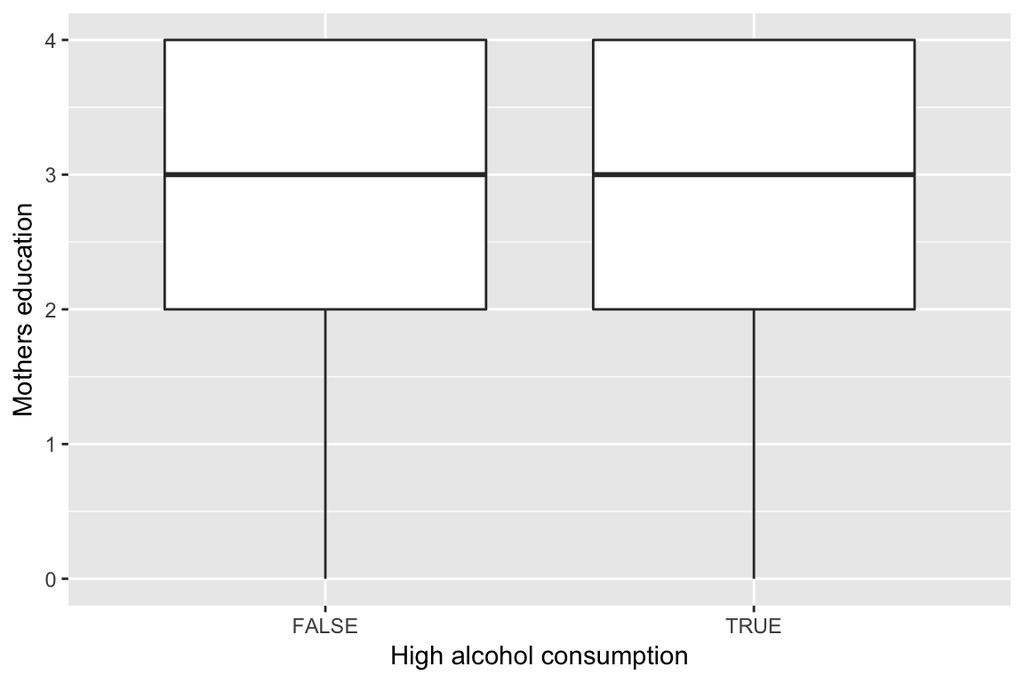

```r
g1me <- ggplot(alc, aes(x = high_use, y = Medu))
g1me + geom_boxplot() + xlab("High alcohol consumption") + ylab("Mothers education")
```

If we look at the mothers education level the results of summary are as follows:

- No education: low drinking n=1 (33%) and high drinking n=2 (67%)
- Primary education (4th grade): low drinking n=33 (65%) and high drinking n= 18 (35%)
- 5th to 9th grade: low drinking n=80 (82%) and high drinking n=18 (18%)
- Secondary education: low drinking n=59 (62%) and high drinking n=36 (38%)
- Higher education: low drinking n=95 (70%) and high drinking n=40 (30%)

So there might be some differences between these groups but ns are quite low, especially in non-educated-group.  
The boxplots of these two alcohol consumption groups look exactly the same.

### Father´s education level

```r
alc %>% group_by(Fedu, high_use) %>% summarise(count = n())
```

```
## Source: local data frame [9 x 3]
## Groups: Fedu [?]
##
##    Fedu high_use count
##   <int>    <lgl> <int>
## 1     0    FALSE     2
## 2     1    FALSE    53
## 3     1     TRUE    24
## 4     2    FALSE    75
## 5     2     TRUE    30
## 6     3    FALSE    72
## 7     3     TRUE    27
## 8     4    FALSE    66
## 9     4     TRUE    33
```

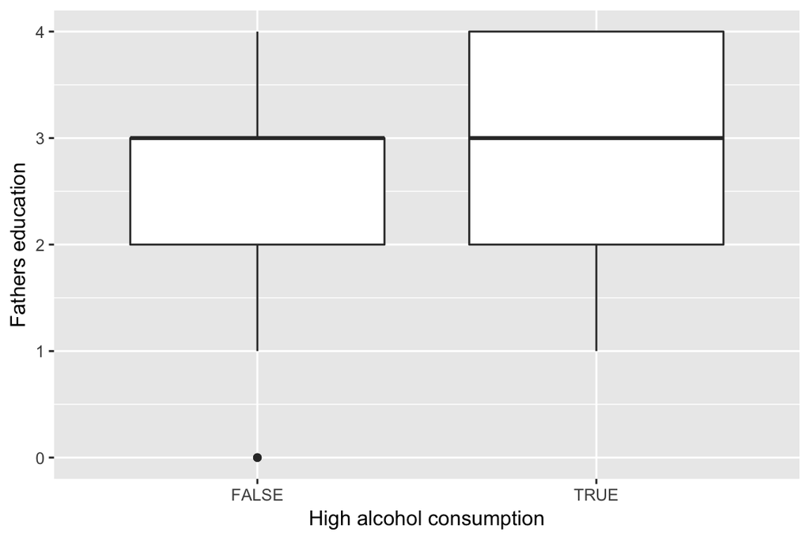

```r
g1fe <- ggplot(alc, aes(x = high_use, y = Fedu))
g1fe + geom_boxplot() + xlab("High alcohol consumption") + ylab("Fathers education")
```

With fathers´education the same numbers are as follows:

- no education: low drinking n=2 (100%) and high drinking n=0
- primary education (4th grade): low drinking n=53 (69%) and high drinking n= 24 (31%)
- 5th to 9th grade: low drinking n=75 (71%) and high drinking n=30 (29%)
- secondary education: low drinking n=72 (73%) and high drinking n=27 (27%)
- higher education: low drinking n=66 (67%) and high drinking n=33 (33%)

So also here we can see that fathers´higher education doesn´t possibly imply lower drinking percentages as opposed to my hypothesis.

### Quality of family relations

```r
alc %>% group_by(famrel, high_use) %>% summarise(count = n())
```

```
## Source: local data frame [10 x 3]
## Groups: famrel [?]
##
##    famrel high_use count
##     <int>    <lgl> <int>
## 1       1    FALSE     6
## 2       1     TRUE     2
## 3       2    FALSE    10
## 4       2     TRUE     9
## 5       3    FALSE    39
## 6       3     TRUE    25
## 7       4    FALSE   135
## 8       4     TRUE    54
## 9       5    FALSE    78
## 10      5     TRUE    24
```

[figure not shown]

```r
g1fr <- ggplot(alc, aes(x = high_use, y = Fedu))
g1fr + geom_boxplot() + xlab("High alcohol consumption") + ylab("Quality of family relations")
```

If we look at the connection between alcohol consumption and quality of family relations distribution in different grade groups are:

- grade 1: low drinkers 6 (75%), high drinkers 2 (25%)
- grade 2: low drinkers 10 (53%), high drinkers 9 (47%)
- grade 3: low drinkers 39 (61%), high drinkers 25 (39%)
- grade 4: low drinkers 135 (71%), high drinkers 54 (29%)
- grade 5: low drinkers 78 (76%), high drinkers 24 (24%)

So there might be some support for my hypothesis that better the family relations lower the alcohol consumption

## Logistic regression and the relationship between the chosen variables and high/low alcohol consumption

```r
m <- glm(high_use ~ Pstatus + Medu + Fedu + famrel, data = alc, family = "binomial")
summary.glm(m)
```

```
##
## Call:
## glm(formula = high_use ~ Pstatus + Medu + Fedu + famrel, family = "binomial",
##     data = alc)
##
## Deviance Residuals:
##     Min       1Q   Median       3Q      Max
## -1.1682  -0.8475  -0.7827   1.4193   1.7343
##
## Coefficients:
##             Estimate Std. Error z value Pr(>|z|)
## (Intercept)  0.10331    0.66634   0.155   0.8768
## PstatusT    -0.04070    0.37567  -0.108   0.9137
## Medu        -0.01669    0.13690  -0.122   0.9029
## Fedu         0.06193    0.13545   0.457   0.6475
## famrel      -0.26540    0.12146  -2.185   0.0289 *
## ---
## Signif. codes:  0 '***' 0.001 '**' 0.01 '*' 0.05 '.' 0.1 ' ' 1
##
## (Dispersion parameter for binomial family taken to be 1)
##
##     Null deviance: 465.68  on 381  degrees of freedom
## Residual deviance: 460.64  on 377  degrees of freedom
## AIC: 470.64
##
## Number of Fisher Scoring iterations: 4
```

```r
coef(m)
```

```
## (Intercept)    PstatusT        Medu        Fedu      famrel
##  0.10331492 -0.04070326 -0.01669495  0.06193416 -0.26540413
```

Only the variable quality of family relations is significant in this model.

### Odds ratios and confidence intervals

```r
OR <- coef(m) %>% exp
CI <- confint(m) %>% exp
cbind(OR, CI)
```

```
##                    OR     2.5 %    97.5 %
## (Intercept) 1.1088405 0.2964832 4.0825324
## PstatusT    0.9601140 0.4688583 2.0693320
## Medu        0.9834436 0.7515044 1.2871504
## Fedu        1.0638923 0.8164830 1.3904537
## famrel      0.7668960 0.6034634 0.9732521
```

Every one of these confidence intervals includes 1 except famrel so it implies these other variables make no difference in the model.

Removing non-significant variables one by one doesn´t give any new variables to the model

```r
m2 <- glm(high_use ~ Medu + Fedu + famrel, data = alc, family = "binomial")
summary.glm(m2)
```

```
##
## Call:
## glm(formula = high_use ~ Medu + Fedu + famrel, family = "binomial",
##     data = alc)
##
## Deviance Residuals:
##     Min       1Q   Median       3Q      Max
## -1.1715  -0.8458  -0.7703   1.4164   1.7327
##
## Coefficients:
##             Estimate Std. Error z value Pr(>|z|)
## (Intercept)  0.06539    0.56687   0.115   0.9082
## Medu        -0.01521    0.13618  -0.112   0.9111
## Fedu         0.06190    0.13546   0.457   0.6477
## famrel      -0.26612    0.12130  -2.194   0.0282 *
## ---
## Signif. codes:  0 '***' 0.001 '**' 0.01 '*' 0.05 '.' 0.1 ' ' 1
##
## (Dispersion parameter for binomial family taken to be 1)
##
##     Null deviance: 465.68  on 381  degrees of freedom
## Residual deviance: 460.65  on 378  degrees of freedom
## AIC: 468.65
##
## Number of Fisher Scoring iterations: 4
```

```r
m3 <- glm(high_use ~ Fedu + famrel, data = alc, family = "binomial")
summary.glm(m3)
```

```
##
## Call:
## glm(formula = high_use ~ Fedu + famrel, family = "binomial",
##     data = alc)
##
## Deviance Residuals:
##     Min       1Q   Median       3Q      Max
## -1.1732  -0.8400  -0.7666   1.4146   1.7244
##
## Coefficients:
##             Estimate Std. Error z value Pr(>|z|)
## (Intercept)  0.04792    0.54493   0.088   0.9299
## Fedu         0.05207    0.10288   0.506   0.6128
## famrel      -0.26610    0.12129  -2.194   0.0282 *
## ---
## Signif. codes:  0 '***' 0.001 '**' 0.01 '*' 0.05 '.' 0.1 ' ' 1
##
## (Dispersion parameter for binomial family taken to be 1)
##
##     Null deviance: 465.68  on 381  degrees of freedom
## Residual deviance: 460.67  on 379  degrees of freedom
## AIC: 466.67
##
## Number of Fisher Scoring iterations: 4
```

So I´ll leave just the variable famrel to the model

```r
m4 <- glm(high_use ~ famrel, data = alc, family = "binomial")
summary.glm(m4)
```

```
##
## Call:
## glm(formula = high_use ~ famrel, family = "binomial", data = alc)
##
## Deviance Residuals:
##     Min       1Q   Median       3Q      Max
## -1.1404  -0.8323  -0.7427   1.4483   1.6869
##
## Coefficients:
##             Estimate Std. Error z value Pr(>|z|)
## (Intercept)   0.1772     0.4812   0.368   0.7127
## famrel       -0.2649     0.1212  -2.185   0.0289 *
## ---
## Signif. codes:  0 '***' 0.001 '**' 0.01 '*' 0.05 '.' 0.1 ' ' 1
##
## (Dispersion parameter for binomial family taken to be 1)
##
##     Null deviance: 465.68  on 381  degrees of freedom
## Residual deviance: 460.92  on 380  degrees of freedom
## AIC: 464.92
##
## Number of Fisher Scoring iterations: 4
```

## The predictive power of my model

```r
probabilities <- predict(m4, type = "response")
alc <- mutate(alc, probability = probabilities)
alc <- mutate(alc, prediction = probability > 0.5)
table(high_use = alc$high_use, prediction = alc$prediction)
```

```
##         prediction
## high_use FALSE
##    FALSE   268
##    TRUE    114
```

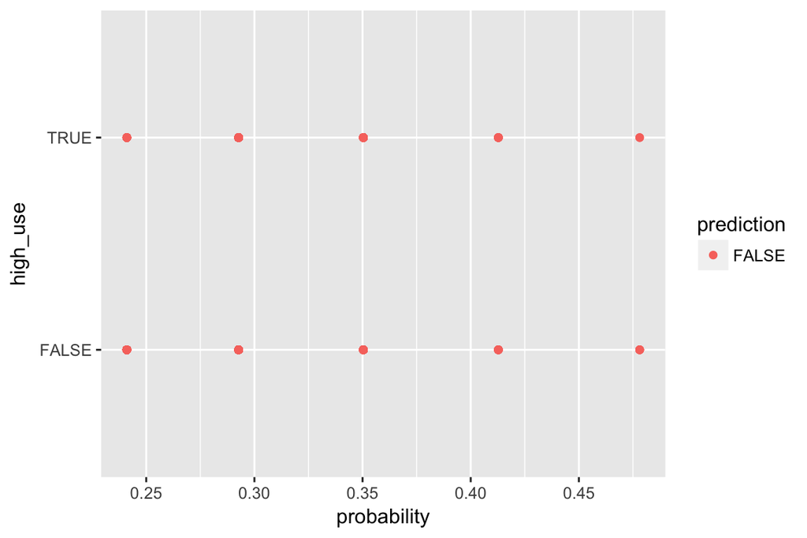

```r
g <- ggplot(alc, aes(x = probability, y = high_use, col = prediction))
g2 <- g + geom_point()
g2
```

```r
table(high_use = alc$high_use, prediction = alc$prediction) %>% prop.table() %>% addmargins()
```

```
##         prediction
## high_use     FALSE       Sum
##    FALSE 0.7015707 0.7015707
##    TRUE  0.2984293 0.2984293
##    Sum   1.0000000 1.0000000
```

```r
m <- glm(high_use ~ failures + absences + sex, data = alc, family = "binomial")
```

So this means that the predictive power of my model is low (and probably more significant variables should be found to make it more predictive.) As long as all the predictions are under 0.5 the level of prediction is same with guessing.

### Mean prediction error

```r
loss_func <- function(class, prob) {
  n_wrong <- abs(class - prob) > 0.5
  mean(n_wrong)
}
loss_func(class = alc$high_use, prob = alc$probability)
```

```
## [1] 0.2984293
```

Mean prediction error is approx. 0.298 which means that so many of predictions are false.

## 10-fold cross validation

```r
cv <- cv.glm(data = alc, cost = loss_func, glmfit = m4, K = 10)
cv$delta[1]
```

```
## [1] 0.2984293
```

### An example of a better model

Another model where prediction error is smaller compared to the model introduced in DataCamp has variables: absences, sex, famrel and goout. It´s prediction error is about 0.207

```r
m5 <- glm(high_use ~ absences + sex + famrel + goout, data = alc, family = "binomial")
summary.glm(m5)
```

```
##
## Call:
## glm(formula = high_use ~ absences + sex + famrel + goout, family = "binomial",
##     data = alc)
##
## Deviance Residuals:
##     Min       1Q   Median       3Q      Max
## -1.7151  -0.7820  -0.5137   0.7537   2.5463
##
## Coefficients:
##             Estimate Std. Error z value Pr(>|z|)
## (Intercept) -2.76826    0.66170  -4.184 2.87e-05 ***
## absences     0.08168    0.02200   3.713 0.000205 ***
## sexM         1.01234    0.25895   3.909 9.25e-05 ***
## famrel      -0.39378    0.14035  -2.806 0.005020 **
## goout        0.76761    0.12316   6.232 4.59e-10 ***
## ---
## Signif. codes:  0 '***' 0.001 '**' 0.01 '*' 0.05 '.' 0.1 ' ' 1
##
## (Dispersion parameter for binomial family taken to be 1)
##
##     Null deviance: 465.68  on 381  degrees of freedom
## Residual deviance: 379.81  on 377  degrees of freedom
## AIC: 389.81
##
## Number of Fisher Scoring iterations: 4
```

```r
cv <- cv.glm(data = alc, cost = loss_func, glmfit = m5, K = 10)
cv$delta[1]
```

```
## [1] 0.2068063
```

# Week 4: Clustering and classification

## Loading the Boston data from the MASS package

```r
setwd("/Users/mirva/IODS-project/")
library(MASS); library(corrplot); library(dplyr); library(ggplot2); library(GGally)
data("Boston")
```

## The structure and the dimensions of the data

```r
str(Boston)
```

```
## 'data.frame':    506 obs. of  14 variables:
##  $ crim   : num  0.00632 0.02731 0.02729 0.03237 0.06905 ...
##  $ zn     : num  18 0 0 0 0 0 12.5 12.5 12.5 12.5 ...
##  $ indus  : num  2.31 7.07 7.07 2.18 2.18 2.18 7.87 7.87 7.87 7.87 ...
##  $ chas   : int  0 0 0 0 0 0 0 0 0 0 ...
##  $ nox    : num  0.538 0.469 0.469 0.458 0.458 0.458 0.524 0.524 0.524 0.524 ...
##  $ rm     : num  6.58 6.42 7.18 7 7.15 ...
##  $ age    : num  65.2 78.9 61.1 45.8 54.2 58.7 66.6 96.1 100 85.9 ...
##  $ dis    : num  4.09 4.97 4.97 6.06 6.06 ...
##  $ rad    : int  1 2 2 3 3 3 5 5 5 5 ...
##  $ tax    : num  296 242 242 222 222 222 311 311 311 311 ...
##  $ ptratio: num  15.3 17.8 17.8 18.7 18.7 18.7 15.2 15.2 15.2 15.2 ...
##  $ black  : num  397 397 393 395 397 ...
##  $ lstat  : num  4.98 9.14 4.03 2.94 5.33 ...
##  $ medv   : num  24 21.6 34.7 33.4 36.2 28.7 22.9 27.1 16.5 18.9 ...
```

```r
dim(Boston)
```

```
## [1] 506  14
```

This data includes 506 observations and 14 variables which are: crim, zn, indus, chas, nox, rm, age, dis, rad, tax, ptratio, black, lstat and medv. You can find the descriptions of the variables [here](https://stat.ethz.ch/R-manual/R-devel/library/MASS/html/Boston.html)